# Reproducible course assignment

Leonardo

23/07/2020

## Loading the dataset

```r
activity = read.csv("C:/Users/Leo/Downloads/repdata_data_activity/activity.csv")
```

The dataset look like this:

```
##   steps       date interval
## 1    NA 2012-10-01        0
## 2    NA 2012-10-01        5
## 3    NA 2012-10-01       10
## 4    NA 2012-10-01       15
## 5    NA 2012-10-01       20
## 6    NA 2012-10-01       25
```

## What is mean total number of steps taken per day?

First, we create an array of the number of steps, by day

```r
summary(activity$steps)
```

```
##    Min. 1st Qu.  Median    Mean 3rd Qu.    Max.    NA's
##    0.00    0.00    0.00   37.38   12.00  806.00    2304
```

```r
count = tapply(activity$steps, activity$date, sum, na.rm=TRUE)
View(count)
```

After we get the mean of the values of steps/day

```r
 mean(count)
```

```
## [1] 9354.23
```

## Make a histogram of the total number of steps taken each day:

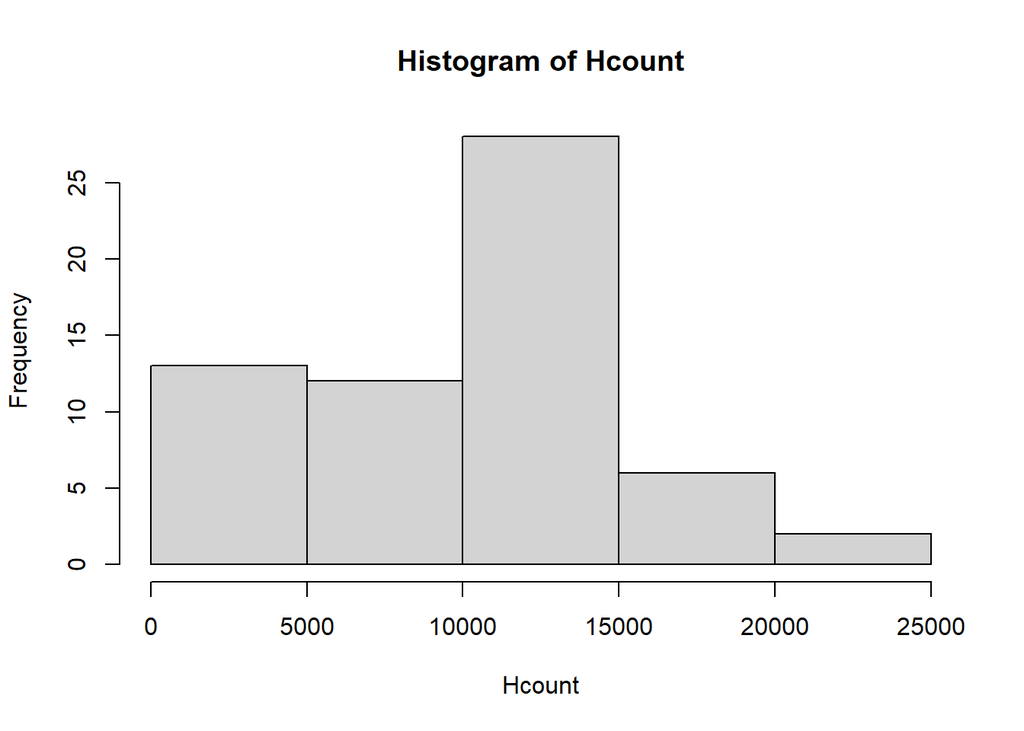

```r
Hcount= as.vector(count)
hist(Hcount)
```

## Calculate and report the mean and median of the total number of steps taken per day

Now we try to discover the mean and median

```r
summary(Hcount)
```

```
##    Min. 1st Qu.  Median    Mean 3rd Qu.    Max.
##       0    6778   10395    9354   12811   21194
```

Or we can use the direct functions

```r
mean(Hcount)
```

```
## [1] 9354.23
```

```r
median(Hcount)
```

```
## [1] 10395
```

## Make a time series plot (i.e. type = “l”) of the 5-minute interval (x-axis) and the average number of steps taken, averaged across all days (y-axis)

Lets calculate the mean steps per interval of the period

```r
smean = as.data.frame(tapply(activity$steps, activity$interval, mean, na.rm=TRUE))
```

## We will need to change the current column name, ad right after include de row names as separate column, and check the data to finish

```r
names(smean)[1] = "mean_values"
smean$interval = row.names(smean)
head(smean)
```

```
##    mean_values interval
## 0    1.7169811        0
## 5    0.3396226        5
## 10   0.1320755       10
## 15   0.1509434       15
## 20   0.0754717       20
## 25   2.0943396       25
```

to the plot part we will use the ggplot2 package

```r
require(ggplot2)
```

plotting the graph using or first dataset

[figure not shown]

```r
ggplot(smean, aes( x = interval,y = mean_values,group = 1))+
  geom_line() +
  scale_x_discrete(breaks = seq(0,2355,150))+
theme_classic()
```

## Which 5-minute interval, on average across all the days in the dataset, contains the maximum number of steps?

Now we obtain the maximum value throught the *smean* dataset

```r
sapply(smean, max, na.rm = FALSE)
```

```
##        mean_values           interval
## "206.169811320755"              "955"
```

## Calculate and report the total number of missing values in the dataset

let’s just sum the numbe of NAs

```r
sum(is.na(activity$steps))
```

```
## [1] 2304
```

## Devise a strategy for filling in all of the missing values in the dataset.

The strategy does not need to be sophisticated. For example, you could use the mean/median for that day, or the mean for that 5-minute interval, etc.

## Create a new dataset that is equal to the original dataset but with the missing data filled in.

We will deal with these parts toghether, filing the NAs as the mean steps of the period

```r
Ractivity = activity
Ractivity[is.na(Ractivity)] = mean(Ractivity$steps, na.rm = TRUE)
head(Ractivity)
```

```
##     steps       date interval
## 1 37.3826 2012-10-01        0
## 2 37.3826 2012-10-01        5
## 3 37.3826 2012-10-01       10
## 4 37.3826 2012-10-01       15
## 5 37.3826 2012-10-01       20
## 6 37.3826 2012-10-01       25
```

## Make a histogram of the total number of steps taken each day and Calculate and report the mean and median total number of steps taken per day

```r
Rmean = tapply(Ractivity$steps, Ractivity$date, sum, na.rm=TRUE)
summary(Rmean)
```

```
##    Min. 1st Qu.  Median    Mean 3rd Qu.    Max.
##      41    9819   10766   10766   12811   21194
```

## Creating the histogram:

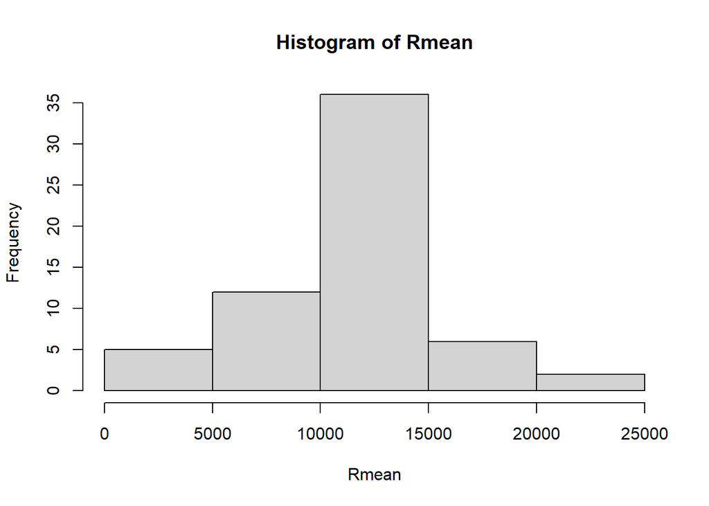

```r
hist(Rmean)
```

#Are there differences in activity patterns between weekdays and weekends? For this part the weekdays() function may be of some help here. Use the dataset with the filled-in missing values for this part.

## Create a new factor variable in the dataset with two levels

“weekday” and “weekend” indicating whether a given date is a weekday or weekend day.

First we will change the dataset to include the dates

```r
datamean= as.data.frame(Rmean)
names(datamean)[1] = "values"
datamean$date = row.names(datamean)
```

we must change the class of the data to date and crate a new colum with the weekdays (only to check) and other as “weekdays” or “weekends”

```r
wkdate = datamean
wkdate$date = as.Date(wkdate$date, format =  c("%Y-%m-%d"))
wkdate$day = weekdays(wkdate$date)
wkdate$class = ifelse(wkdate$day %in% c("segunda-feira","terça-feira","quarta-feira","quinta-feira","sexta-feira"), "weekday", "weekend")
```

Although the last step could be simplified to:

```r
wkdate$class = ifelse(wkdate$day %in% c("sábado", "domingo"), "weekend", "weekday")
```

now we include the new column as the weekdays or weekends

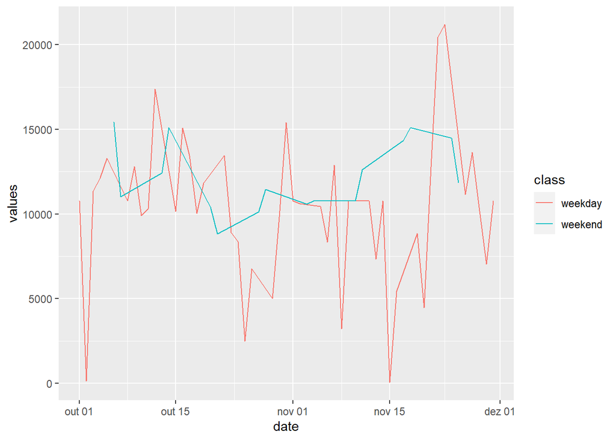

```r
ggplot(wkdate, aes(x= date, y= values))+ geom_line(aes(color = class))
```